# Intro to Conjoint Experiments | ECPR LAB - Session 2

# 1 Setting up R

## 1.1 Why R

- Free and open source (think of science in developing countries)
- Good online-documentation (much better than some commercial softwere such as Mplus)
- Lively community of users (forums etc.)
- Visualization capabilities (ggplot …)
- Cooperates with other programs and programming language (e.g. Python)
- Popularity (See popularity statistics on books, blogs, forums)
- RStudio as powerful integrated development environment (IDE) for R
- Evolves into a scientific work suite optimizing workflow (replication, reproducability etc.)
- Institutions/people (Gary King, Andrew Gelman etc.)
- Economic power (Revolution Analytics, Microsoft R Open)

## 1.2 Where to study it

- If you haven’t used R sofar it’s necessary that you learn some basics in R.
- Data Camp (free trial but it is commercial)
- Try R: A short interactive intro to the language can be found here: http://tryr.codeschool.com/
- Swirl: Learn R interactively within R itself: http://swirlstats.com/
- Akos Mate ECPR R basic for the next 2 months https://github.com/aakosm/R_Basics_ECPR

## 1.3 Install R on your Machine

Below some notes on the installation and setup of R and relevant packages on your own computer:

- Install Rtools for Windows machines from CRAN (https://cran.r-project.org/bin/windows/Rtools/).
- If you are using OS X, you will need to to install XCode, available for free from the App Store. This will install a compiler (if you don’t have a compiler installed) which will be needed when installing packages from GitHub that require compilation from C++ source code.
- Install the latest version of R from CRAN (https://cran.r-project.org/).
- Install the latest version of RStudio (https://www.rstudio.com/products/RStudio/). RStudio is the editor we’ll rely on, i.e. we’ll write code in RStudio which is subsequently sent to and run within R.
- Install the latest versions of various packages that we need. You can also update your packages by running “update.packages(ask = FALSE)” in the R commandline.

```r
# A function to install the required packages
# you don't need to understand what it does
ipak <- function(pkg){
  new.pkg <- pkg[!(pkg %in% installed.packages()[, "Package"])]
  if (length(new.pkg))
    install.packages(new.pkg, dependencies = TRUE,repos = c(
  CRAN = 'https://cran.rstudio.com',
  CRANextra = 'https://macos.rbind.io'
)
      )
  sapply(pkg, require, character.only = TRUE)
}


packages_needed <- c("foreign",
                     "readr",
                     "plyr",
                     "dplyr",
                     "tidyr",
                     "tibble",
                     "knitr",
                     "printr",
                     "stargazer",
                     "ggplot2",
                     "MatchIt",
                     "rmarkdown",
                     "repmis")

ipak(packages_needed)
```

```
  foreign     readr      plyr     dplyr     tidyr    tibble     knitr    printr stargazer   ggplot2   MatchIt rmarkdown    repmis
     TRUE      TRUE      TRUE      TRUE      TRUE      TRUE      TRUE      TRUE      TRUE      TRUE      TRUE      TRUE      TRUE
```

```r
  # Data import
    library(foreign)
    library(haven)
    library(readr)
    library(qualtRics)

  # Data management
    library(plyr)
    library(dplyr)
    library(tidyr)
    library(tibble)
    library(reshape2)
    library(tidyselect)
    library(knitr)
    library(psych)
  # Visualization
    library(ggplot2)
    library(stargazer)
  # Report
    library(report)
  # Conjoint Analysis
    library(cjoint)
```

# 2 What we are going to do in this LAB

1. Data Management
2. From Qualtrics
3. From Other Sources
4. Get the data ready for CJ Analysis
5. Validity checks
6. From Wide to Long
7. Perform the analysis in R
   1. AMCE
   2. Attributes interactions Conditional AMCE

## 2.1 Dataset used

1. 2018 CEU Experimental Political Science dataset
   1. Q578 Q579 Q580: Choice CJ Task
   2. F-*-*: Conjoint features
   3. Q78: Employment status
   4. Q77: Race
   5. Q76: Education
   6. Q75: Gender
   7. Q74: Age
   8. Q581: Religiosity

# 3 Load the data: Qualtrics

- Let’s take a look to how to deal with the Qualtrics format
  - Qualtrics include HTML tags that are use for diagnostics
  - We need to get rid of them
  - We are going to use the **qualtRics** package for removing the tags

```r
library(qualtRics)

download.file("https://drive.google.com/uc?export=download&id=1MUkRNTnF4C2MeAloj6qmfKfp3QuhJJnh","ceu_data.csv")

df_base <- qualtRics::read_survey("ceu_data.csv", # name of our data file
    legacy=FALSE, # new or old version of Qualtrics
    strip_html=TRUE # remove the html tag
)

head(df_base)
```

| Duration (in seconds) | Finished | ResponseId | Q578 | Q579 | Q580 | Q271_1 | Q271_2 | Q271_3 | Q271_4 | Q271_5 | Q271_6 | Q78 | Q77 | Q76 | Q75 | Q74 | Q581 | F-1-1 | F-1-1-1 | F-1-2 | F-1-1-2 | F-1-3 | F-1-1-3 | F-1-2-1 | F-1-2-2 | F-1-2-3 | F-2-1 | F-2-1-1 | F-2-2 | … |
| --- | --- | --- | --- | --- | --- | --- | --- | --- | --- | --- | --- | --- | --- | --- | --- | --- | --- | --- | --- | --- | --- | --- | --- | --- | --- | --- | --- | --- | --- | --- |
| 227 | TRUE | R_2rzostKYTJLvQPv | Candidate 2 | Candidate 2 | Candidate 1 | 4 - Neither agree nor disagree | 6 | 3 | 5 | 3 | 5 | Employed, full-time | Hispanic | Master degree | Female | 25 | Regularly | Penal proceedings | The candidate has been convicted of corruption | Past Political Experience | Approximately 20 years | Policy Proposal | Acceptance of immigrants conditional on certain requisites | The candidate is under investigation for corruption | Approximately 10 years | Collective expulsion of immigrants and closure of the border | Penal proceedings | No proceedings | Past Political Experience | … |
| 195 | TRUE | R_5dluK6RwY8Kibol | Candidate 1 | Candidate 2 | Candidate 2 | 5 | 3 | 2 | 4 - Neither agree nor disagree | 2 | 5 | Unemployed | Caucasian | Some high school | Male | 28 | Never | Policy Proposal | Collective expulsion of immigrants and closure of the border | Penal proceedings | The candidate is under investigation for corruption | Past Political Experience | Approximately 20 years | Welcome immigrants and organise human corridor | The candidate has been convicted of corruption | None | Policy Proposal | Acceptance of immigrants conditional on certain requisites | Penal proceedings | … |
| 295 | TRUE | R_3QMq6EzoaEhTjSI | Candidate 2 | Candidate 1 | Candidate 1 | 6 | 6 | 6 | 6 | 3 | 5 | Student | Caucasian | Some college | Male | 22 | Never | Past Political Experience | None | Policy Proposal | Welcome immigrants and organise human corridor | Penal proceedings | The candidate is under investigation for corruption | Approximately 10 years | Acceptance of immigrants conditional on certain requisites | No proceedings | Past Political Experience | Approximately 10 years | Policy Proposal | … |
| 358 | TRUE | R_2ZWYdunD4yrjLI3 | Candidate 1 | Candidate 1 | Candidate 2 | 6 | 3 | 3 | 6 | 1 - Strongly disagree | 7 - Strongly agree | Unemployed | Caucasian | Some college | Male | 32 | Never | Past Political Experience | Approximately 10 years | Penal proceedings | No proceedings | Policy Proposal | Welcome immigrants and organise human corridor | Approximately 10 years | The candidate is under investigation for corruption | Acceptance of immigrants conditional on certain requisites | Past Political Experience | Approximately 20 years | Penal proceedings | … |
| 310 | TRUE | R_3GEedrAF3Om8dOt | Candidate 2 | Candidate 2 | Candidate 1 | 6 | 3 | 6 | 5 | 3 | 6 | Student | Asian | Some college | Male | 21 | Never | Penal proceedings | The candidate is under investigation for corruption | Past Political Experience | None | Policy Proposal | Acceptance of immigrants conditional on certain requisites | No proceedings | None | Acceptance of immigrants conditional on certain requisites | Penal proceedings | The candidate has been convicted of corruption | Past Political Experience | … |
| 365 | TRUE | R_emv0H4GnLSxqphv | Candidate 2 | Candidate 1 | Candidate 1 | 6 | 5 | 5 | 4 - Neither agree nor disagree | 5 | 5 | Employed, full-time | Caucasian | Some college | Male | 30 | Regularly | Past Political Experience | None | Policy Proposal | Acceptance of immigrants conditional on certain requisites | Penal proceedings | The candidate is under investigation for corruption | None | Collective expulsion of immigrants and closure of the border | No proceedings | Past Political Experience | Approximately 10 years | Policy Proposal | … |

# 4 Checks and Data Manipulation

## 4.1 Validity Checks

- We are going to try to detect abnormal patterns in the survey duration
  - Exclude respondents who did not completed the survey or were too fast in completing it
  - Exclude observations that took too long to complete the survey

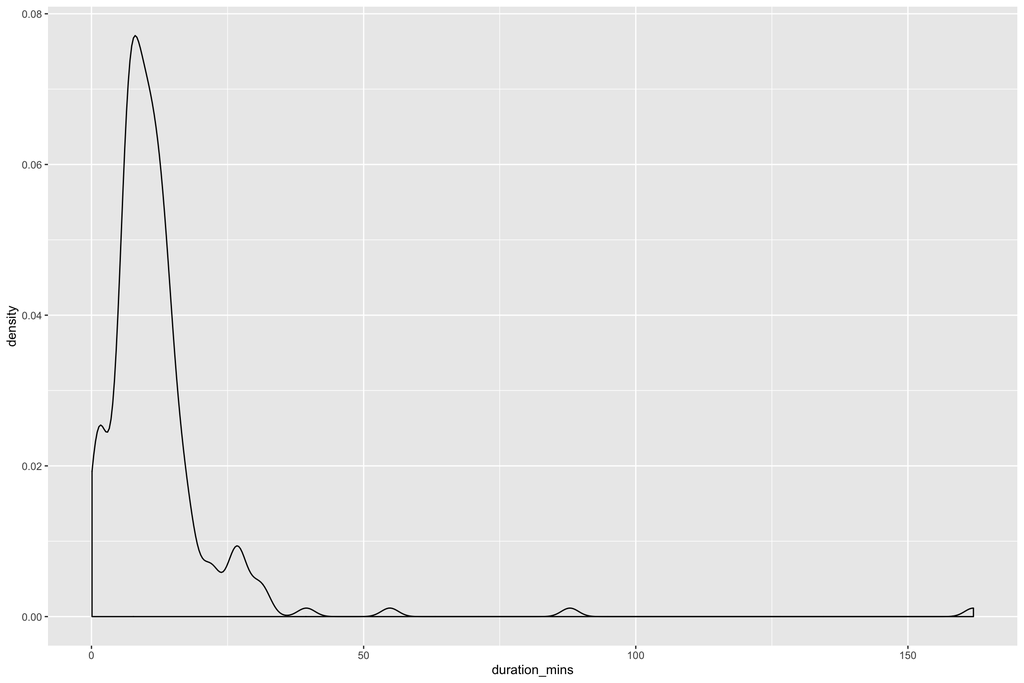

```r
# duration of the survey in seconds
df_base$"Duration (in seconds)" <- as.numeric(df_base$"Duration (in seconds)")
# let's transform it in minutes
df_base$duration_mins <-  df_base$"Duration (in seconds)"/60
# plot the density
ggplot(df_base, aes(x=duration_mins)) +
  geom_density()
```

1. The survey has been tested and it was estimated to take between 8 and 15 mins to be completed
2. Q: What can you see from the graph above?
3. We are going to exclude outliers
   1. Less than 4 mins
   2. More than 3 standard deviation above the mean

```r
# calculate the % of respondents that completed the survey in less than 4 minutes
(sum(df_base$duration_mins < 4)/nrow(df_base)*100)
```

```
[1] 11.71171
```

```r
# select the observations that completed the survey in more than 4 minutes
lower_bound <- df_base$duration_mins > 4
# subset the observation keeping only the observation that completed the survey in more than 4 minutes
df_greater_base <- df_base[lower_bound,]
# to get the upper bound we resort on another approach
# scale a z-scores
df_greater_base$scaled_duration_mins <- scale(df_greater_base$duration_mins)
# calculate the % of respondents that are 3 sd or more from the mean
(sum(df_greater_base$scaled_duration_mins > 3)/nrow(df_greater_base)*100)
```

```
[1] 1.530612
```

```r
# upper bound
upper_bound <- df_greater_base$scaled_duration_mins < 3
# subset the observation keeping only the observation that completed the survey in no more than 3 sd from the mean
df_greater_base <- df_greater_base[upper_bound,]
```

## 4.2 Removing NA on the DV

- Calculate how many respondents did not answer the CJ questions

```r
(sum(is.na(df_greater_base$Q578))/nrow(df_greater_base)*100)
```

```
[1] 4.145078
```

```r
(sum(is.na(df_greater_base$Q579))/nrow(df_greater_base)*100)
```

```
[1] 4.145078
```

```r
(sum(is.na(df_greater_base$Q580))/nrow(df_greater_base)*100)
```

```
[1] 3.626943
```

- The similarity in the % suggests that a unique number of respondets did not complete the survey
- This is good news but let’s check if this is the case
- Let investigate which respondents did not answer the CJ questions

```r
df_greater_base[is.na(df_greater_base$Q578),"ResponseId"]
```

| ResponseId |
| --- |
| R_3dEN4IvpNRlrYGZ |
| R_24GD2YvqjePlgR8 |
| R_9QSDhesusl6rm8N |
| R_2QMWfW6np5x4tOU |
| R_1r8icC6TonV8OPo |
| R_2S3ngM3YxFabDkc |
| R_3nDDFSDtufMIwpL |
| R_3QPGHPBx2jnXRIQ |

```r
df_greater_base[is.na(df_greater_base$Q579),"ResponseId"]
```

| ResponseId |
| --- |
| R_3dEN4IvpNRlrYGZ |
| R_24GD2YvqjePlgR8 |
| R_9QSDhesusl6rm8N |
| R_2QMWfW6np5x4tOU |
| R_1r8icC6TonV8OPo |
| R_2S3ngM3YxFabDkc |
| R_3nDDFSDtufMIwpL |
| R_3QPGHPBx2jnXRIQ |

```r
df_greater_base[is.na(df_greater_base$Q580),"ResponseId"]
```

| ResponseId |
| --- |
| R_3dEN4IvpNRlrYGZ |
| R_24GD2YvqjePlgR8 |
| R_9QSDhesusl6rm8N |
| R_2QMWfW6np5x4tOU |
| R_1r8icC6TonV8OPo |
| R_3nDDFSDtufMIwpL |
| R_3QPGHPBx2jnXRIQ |

```r
df_greater_base_wo_NA <- df_greater_base[!is.na(df_greater_base$Q578),]
df_greater_base_wo_NA <- df_greater_base_wo_NA[!is.na(df_greater_base_wo_NA$Q579),]
df_greater_base_wo_NA <- df_greater_base_wo_NA[!is.na(df_greater_base_wo_NA$Q580),]
```

## 4.3 Get the data in the right format

- Transform the DV in numeric format.
  - This is required by the read.df.qualtRics() function
- Recode the moderators if you plan to use them in the analysis
  - We are going to use education as moderator
  - I am interesting in comparing respondents with high and low levels of education

```r
df_greater_base_wo_NA$Q578 <- as.numeric(as.factor(df_greater_base_wo_NA$Q578))
df_greater_base_wo_NA$Q579 <- as.numeric(as.factor(df_greater_base_wo_NA$Q579))
df_greater_base_wo_NA$Q580 <- as.numeric(as.factor(df_greater_base_wo_NA$Q580))

df_greater_base_wo_NA$education_recoded <- ifelse(df_greater_base_wo_NA$Q76=="Bachelor degree"| df_greater_base_wo_NA$Q76=="PhD, JD, MD"| df_greater_base_wo_NA$Q76=="Master degree", "Higher Education", "Lower Education")

df_greater_base_wo_NA$education_recoded <- as.factor(df_greater_base_wo_NA$education_recoded)
```

- Let’s take a look at the recoded data
- Everything seems in order

```r
psych::describe(with(df_greater_base_wo_NA, cbind(Q578,Q579,Q580,education_recoded)))
```

|  | vars | n | mean | sd | median | trimmed | mad | min | max | range | skew | kurtosis | se |
| --- | --- | --- | --- | --- | --- | --- | --- | --- | --- | --- | --- | --- | --- |
| Q578 | 1 | 185 | 1.513513 | 0.5011737 | 2 | 1.516779 | 0 | 1 | 2 | 1 | -0.0536360 | -2.007889 | 0.0368470 |
| Q579 | 2 | 185 | 1.556757 | 0.4981163 | 2 | 1.570470 | 0 | 1 | 2 | 1 | -0.2266537 | -1.959131 | 0.0366222 |
| Q580 | 3 | 185 | 1.464865 | 0.5001175 | 1 | 1.456376 | 0 | 1 | 2 | 1 | 0.1397480 | -1.991146 | 0.0367694 |
| education_recoded | 4 | 184 | 1.467391 | 0.5002969 | 1 | 1.459459 | 0 | 1 | 2 | 1 | 0.1296489 | -1.993939 | 0.0368824 |

## 4.4 From wide to long

- We need to use a “staked” design because we have respondents answering multiple CJ task

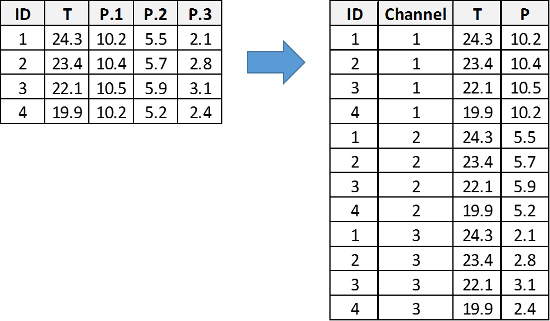

- We are going to achieve this using the custom made function read.df.qualtRics()
- Four arguments
  - data frame
  - responses: the choice task variables
  - covariates: the moderators
  - respondentID: the respondent unique identifier

```r
df_long_format <- read.df.qualtRics(df_greater_base_wo_NA,
  # the DV for our conjoint tasks (Candidate 1 and Candidate 2)
  responses=c("Q578","Q579","Q580"),
  covariates=c("Q76"),
  respondentID = "ResponseId"
  )
```

- The read.df.qualtRics transforms the textual information inside the CJ cells into factors with N levels
- Relevant attributes of the read.df.qualtRics function:
  - selected: Our DV. If the profile was selected or not (in this case: Q578,Q579,Q580)
  - respondent: unique ID
  - task: which task the respondent is performing (cognitive fatigue)
  - .rowpos: position in the CJ table row of the attribute (ordering effect)
  - profile: which profile we are referring to (left-right carry over)
  - a set of factors that will be our IVs
- Let’s see how it looks for respondent 1 in our DF

```r
# let's order according to the respondent ID
respondent_1 <- df_long_format[order(df_long_format$respondent),]
# let's check respondent 1
kable(respondent_1[1:6,],digits=2)
```

|  | ResponseId | Q76 | task | respondent | profile | Past.Political.Experience | Past.Political.Experience.rowpos | Penal.proceedings | Penal.proceedings.rowpos | Policy.Proposal | Policy.Proposal.rowpos | selected | respondentIndex |
| --- | --- | --- | --- | --- | --- | --- | --- | --- | --- | --- | --- | --- | --- |
| 1 | R_3QMq6EzoaEhTjSI | Some college | 1 | 1 | 1 | None | 1 | The candidate is under investigation for corruption | 3 | Welcome immigrants and organise human corridor | 2 | 0 | 1 |
| 186 | R_3QMq6EzoaEhTjSI | Some college | 2 | 1 | 1 | Approximately 10 years | 1 | The candidate has been convicted of corruption | 3 | Acceptance of immigrants conditional on certain requisites | 2 | 1 | 1 |
| 371 | R_3QMq6EzoaEhTjSI | Some college | 3 | 1 | 1 | Approximately 20 years | 1 | No proceedings | 3 | Collective expulsion of immigrants and closure of the border | 2 | 1 | 1 |
| 556 | R_3QMq6EzoaEhTjSI | Some college | 1 | 1 | 2 | Approximately 10 years | 1 | No proceedings | 3 | Acceptance of immigrants conditional on certain requisites | 2 | 1 | 1 |
| 741 | R_3QMq6EzoaEhTjSI | Some college | 2 | 1 | 2 | Approximately 20 years | 1 | No proceedings | 3 | Welcome immigrants and organise human corridor | 2 | 0 | 1 |
| 926 | R_3QMq6EzoaEhTjSI | Some college | 3 | 1 | 2 | Approximately 10 years | 1 | The candidate has been convicted of corruption | 3 | Welcome immigrants and organise human corridor | 2 | 0 | 1 |

# 5 Estimating the AMCE

## 5.1 AMCE: Baseline effects

- The baseline AMCE represent the averaged effect of **varying** one attributes on the probability that that profile is chosen by a respondent, marginalizing over all the other attributes
- Again: It is NOT a descriptive measures BUT a casual estimand

```r
results <- amce(selected ~ Past.Political.Experience + Penal.proceedings + Policy.Proposal,
  data=df_long_format,
  cluster=TRUE,
  respondent.id="ResponseId"
)

summary(results)
```

```
------------------------------------------
Average Marginal Component Effects (AMCE):
------------------------------------------
                 Attribute                                                        Level  Estimate Std. Err   z value   Pr(>|z|)
 Past.Political.Experience                                       Approximately 20 years  0.011326 0.033881   0.33428 7.3816e-01
 Past.Political.Experience                                                         None -0.126223 0.030292  -4.16694 3.0872e-05 ***
         Penal.proceedings               The candidate has been convicted of corruption -0.410547 0.033176 -12.37481 3.5774e-35 ***
         Penal.proceedings          The candidate is under investigation for corruption -0.296646 0.034319  -8.64375 5.4398e-18 ***
           Policy.Proposal Collective expulsion of immigrants and closure of the border -0.271236 0.038193  -7.10169 1.2324e-12 ***
           Policy.Proposal               Welcome immigrants and organise human corridor -0.078578 0.038786  -2.02593 4.2772e-02   *
---
Number of Obs. = 1110
---
Number of Respondents = 185
---
Signif. codes: 0 '***' 0.001 '**' 0.01 '*' 0.05

--------------------
AMCE Baseline Levels:
--------------------
                 Attribute                                                      Level
 Past.Political.Experience                                     Approximately 10 years
         Penal.proceedings                                             No proceedings
           Policy.Proposal Acceptance of immigrants conditional on certain requisites
```

# 6 Your turn

## 6.1 Data

1. From the paper “The Ties that Double Bind”
2. We are going to use the Legislators and Voters sample
3. The authors want to test different type of gender biases
   - Among Legislators
   - Among Voters

| Attribute | Values |
| --- | --- |
| Gender | Female, Male |
| Age | 29, 45, 65 |
| Number of Children | 0, 1, 3 |
| Highest Elected Political Post | None, Mayor, State Legislator |
| Occupation | Corporate Lawyer, Third Grade Teacher |
| Spouse’s Occupation | Doctor, Farmer, Unmarried |

- Variables in the dataset
  - CJ choice task= “winner”
  - Type of sample = “sample”
  - Respondent’s gender=“female_respondent”
  - Respondent’s PID= “democrat_respondent”, “republican_respondent”
  - Candidate’s gender= “orig_cand_female”
  - Political Experience= “orig_0ys”, “orig_1ys”, “orig_3ys”, “orig_8ys”
  - Number of Children= “orig_0ch”, “orig_1ch”, “orig_3ch”
  - Political Post= “orig_may”, “orig_leg”
  - Occupation= “orig_law”, “orig_teach”
  - Spouse’s Occupation= “orig_UN_sp”, “orig_FM_sp”, “orig_MD_sp”
  - Candidate’s Age= “orig_29”, “orig_45”, orig_65"

## 6.2 Task

1. Postulate Hypothesises/Expectation
2. Estimate the AMCE for the candidates’ traits
   - See if your Hypothesises/Expectation hold
3. Re-estimate the AMCE using a simple OLS
   - What happened?
4. [OPTIONAL] Estimate the AMCE in the voter sample
   - Are there any differences?

```r
# load the data
teele_data <- readr::read_csv(sprintf("https://drive.google.com/uc?export=download&id=1ZFbtJ6_kCy4-JH6p9McikXvS1YfOgvcl"
))
# store in an object
data_teele_legislator <- subset(teele_data, sample == "usa leg")
data_teele_legislator <- subset(data_teele_legislator, replication == 0)
```

Alberto Stefanelli and Martin Lukac